# Axis & Plot Labels

## Axis Labels

The axis labels can be modified using the `xlab()` and `ylab()` functions.

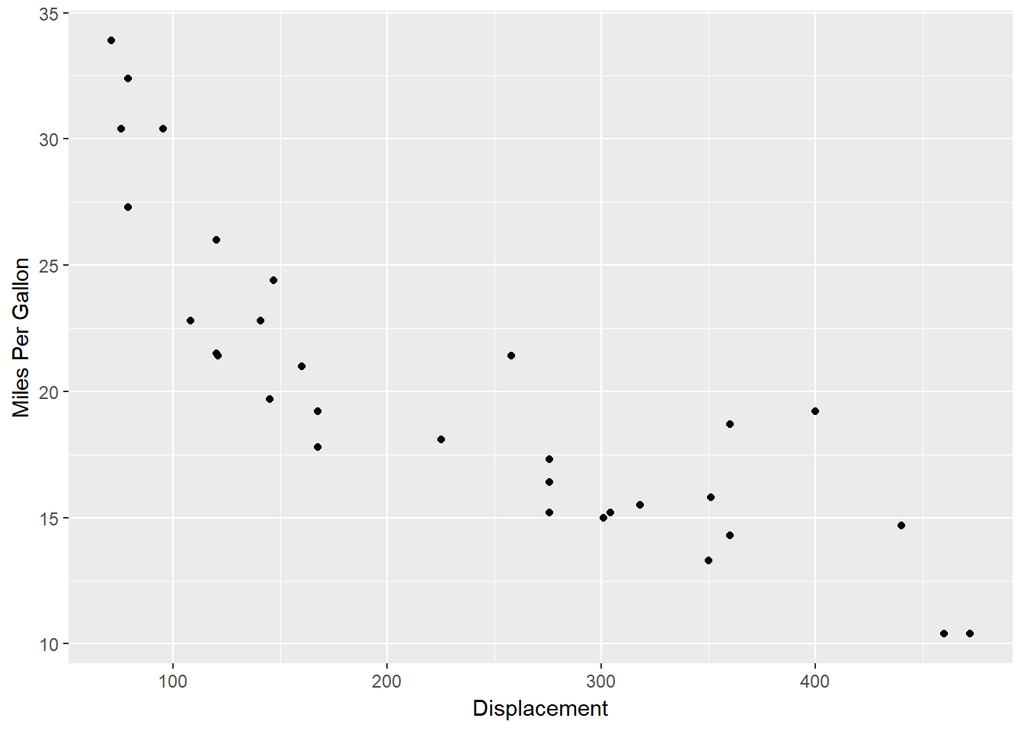

```r
ggplot(mtcars) +
  geom_point(aes(disp, mpg)) +
  xlab('Displacement') + ylab('Miles Per Gallon')
```

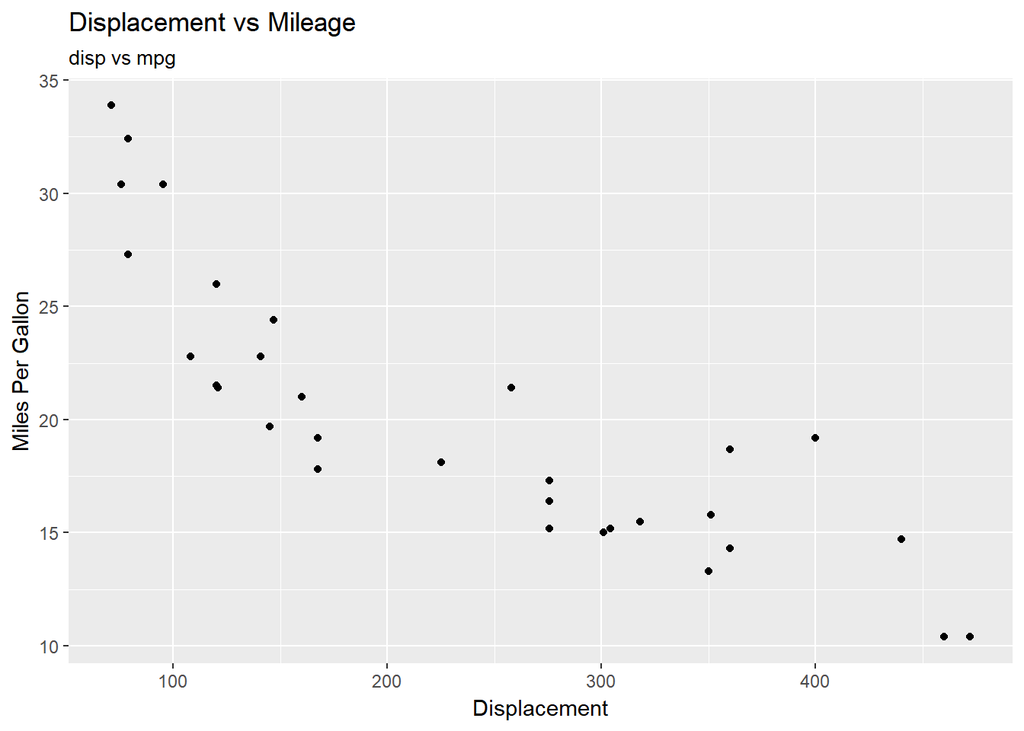

```r
ggplot(mtcars) +
  geom_point(aes(disp, mpg)) +
  labs(title = 'Displacement vs Mileage',
    subtitle = 'disp vs mpg', x = 'Displacement',
    y = 'Miles Per Gallon')
```

## Axis Range

Sometimes you may want to modify the range of the axis.

Use the `xlim()` function to modify the range of the X axis.

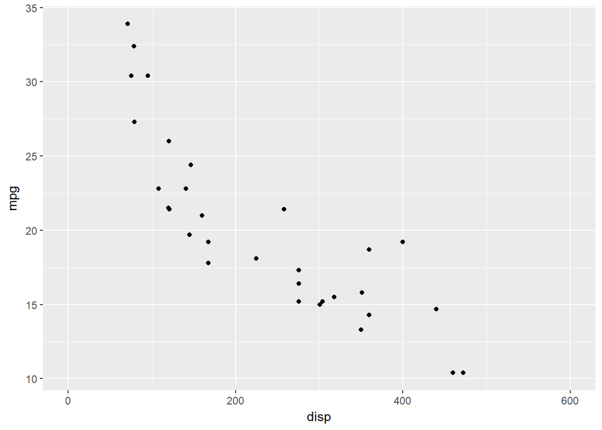

```r
ggplot(mtcars) +
  geom_point(aes(disp, mpg)) +
  xlim(c(0, 600))
```

Use the `ylim()` function to modify the range of the Y axis.

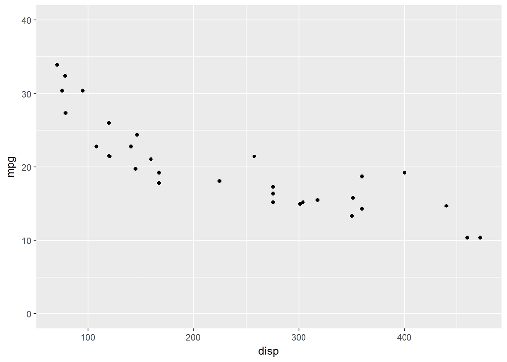

```r
ggplot(mtcars) +
  geom_point(aes(disp, mpg)) +
  ylim(c(0, 40))
```

You can use the `expand_limits()` function as well.

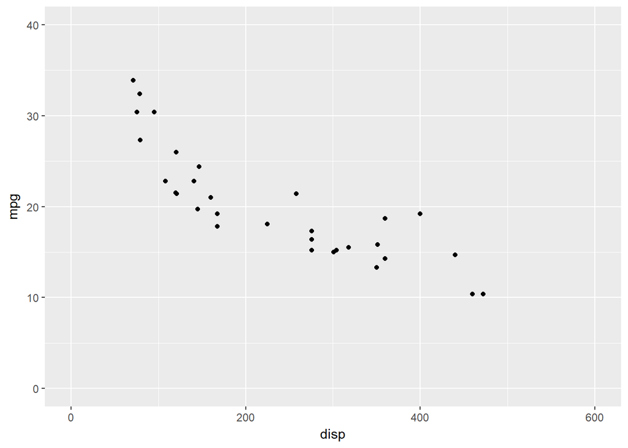

```r
ggplot(mtcars) +
  geom_point(aes(disp, mpg)) +
  expand_limits(x = c(0, 600), y = c(0, 40))
```

## Remove Axis Labels

If you want to remove the axis labels all together, use the `theme()` function.

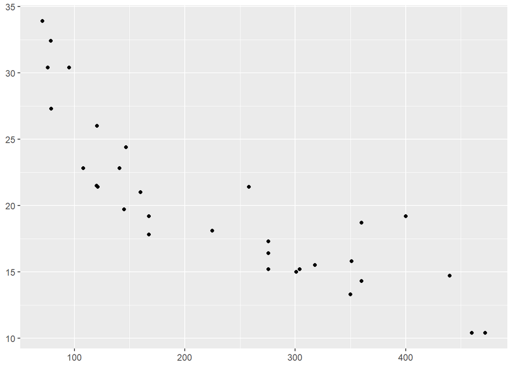

```r
ggplot(mtcars) +
  geom_point(aes(disp, mpg)) +
  theme(axis.title.x = element_blank(),
    axis.title.y = element_blank())
```

What we are doing above is to modify the theme of the plot and set the axis labels to blank using `element_blank()` function.

## Format Title & Axis Labels

To format the title or the axis labels, we have to modify the theme of the plot using the `theme()` function. We can modify the color, font family, font face, font size and horizontal position. Let us try them one by one.

The font family can be any of the valid font family types but it must be supported by OS. The font face can be plain, bold, italic, bold.italic hjust must be between 0 (extreme left) and 1 (extreme right).

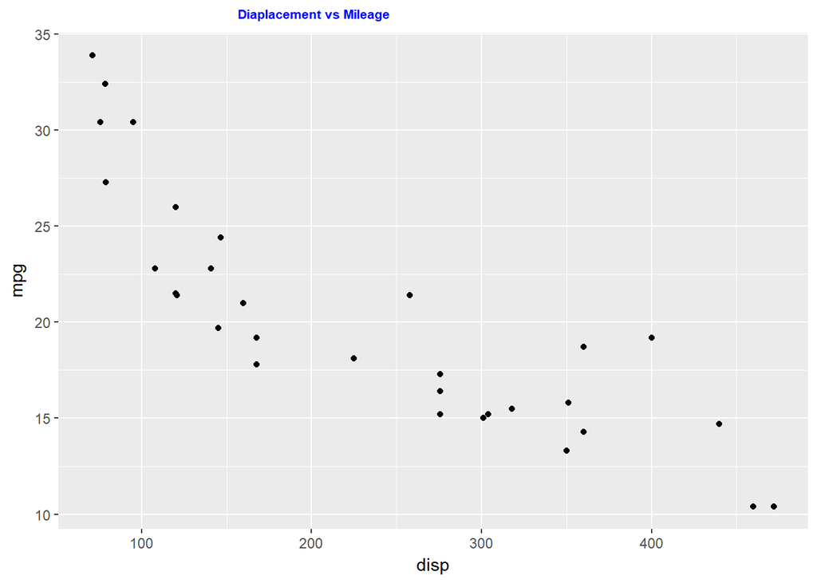

```r
ggplot(mtcars) +
  geom_point(aes(disp, mpg)) +
  ggtitle('Diaplacement vs Mileage') +
  theme(plot.title = element_text(color = 'blue',
                                  family = 'Arial',
                                  face = 'bold',
                                  size = 8,
                                  hjust = 0.3))
```

X axis label.

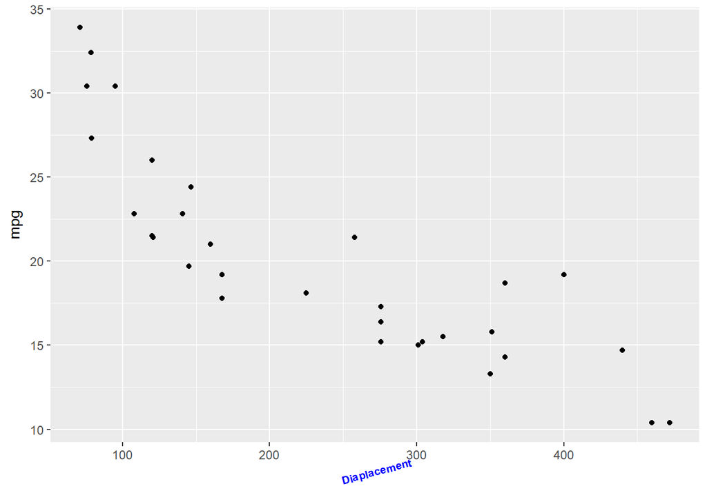

```r
ggplot(mtcars) +
  geom_point(aes(disp, mpg)) +
  xlab('Diaplacement') +
  theme(axis.title.x = element_text(color = 'blue',
                                  family = 'Arial',
                                  face = 'bold',
                                  size = 8,
                                  hjust = 0.5,
                                  angle = 15))
```

Y axis label.

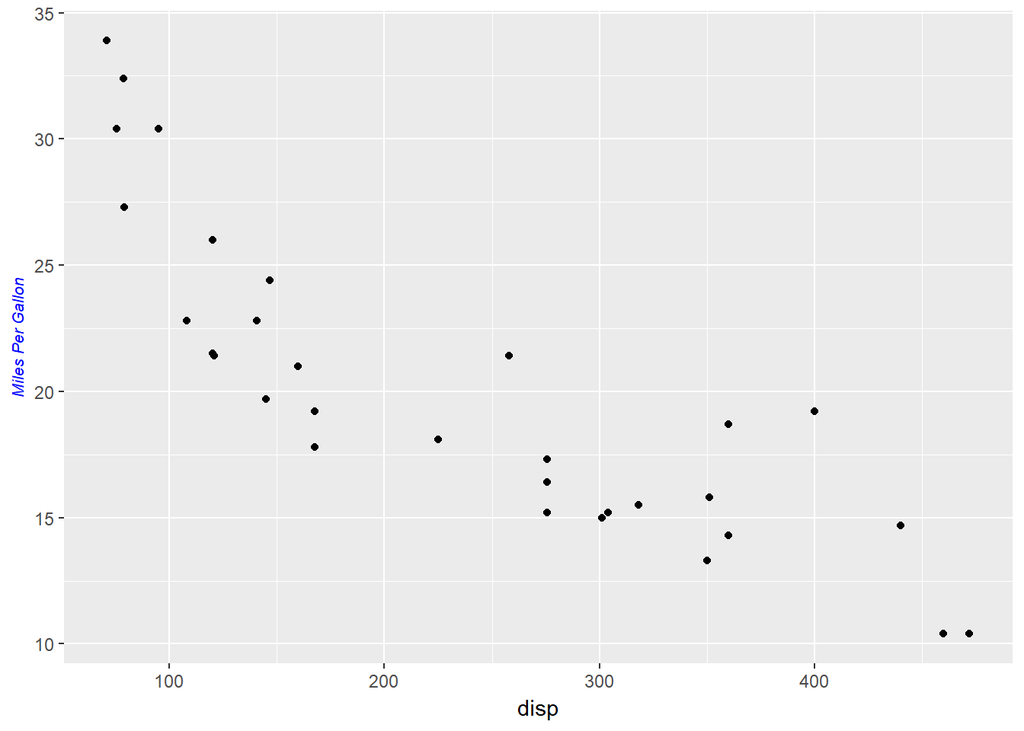

```r
ggplot(mtcars) +
  geom_point(aes(disp, mpg)) +
  ylab('Miles Per Gallon') +
  theme(axis.title.y = element_text(color = 'blue',
                                  family = 'Arial',
                                  face = 'italic',
                                  size = 8,
                                  vjust = 0.3,
                                  angle = 90))
```